# Paris Rivera

```python
# Paso 1: Instalación de dependencias necesarias
!pip install pygbif pandas geopandas rasterio folium matplotlib seaborn
```

[output not shown]

```python
# Importación de librerías
import pandas as pd
import geopandas as gpd
import rasterio
import folium
import matplotlib.pyplot as plt
import seaborn as sns
from pygbif import occurrences
from shapely.geometry import Point
```

```python
# 2: Definir la especie de estudio
taxon_name = "crocodylus acutus"  #(Cocodrilo americano) → Habita manglares y ríos en América.
limit = 400 # Número de registros a recuperar
```

Cocodrilo americano

[figure not shown]

```python
# Obtener datos de ocurrencias de la especie desde GBIF
data = occurrences.search(scientificName=taxon_name, limit=limit)

# Convertir los datos en un DataFrame de pandas
df = pd.DataFrame(data["results"])

# Filtrar solo las columnas importantes y eliminar valores nulos
df = df[['year', 'country', 'decimalLatitude', 'decimalLongitude']].dropna()
```

```python
# 3: Visualización de datos en tablas
print("Primeras 10 filas de los datos obtenidos:")
print(df.head(10))
```

```
Primeras 10 filas de los datos obtenidos:
   year                   country  decimalLatitude  decimalLongitude
0  2025                Costa Rica         9.974599        -84.768074
1  2025                Costa Rica         9.991762        -84.693347
2  2025                Costa Rica        10.440814        -83.561761
3  2025  United States of America        26.094581        -81.768940
4  2025                    Mexico        20.666279       -105.249776
5  2025  United States of America        25.798816        -80.050613
6  2025  United States of America        25.682305        -80.703266
7  2025  United States of America        25.618440        -80.312925
8  2025                    Panama         8.289574        -82.528147
9  2025                   Jamaica        18.013030        -77.846584
```

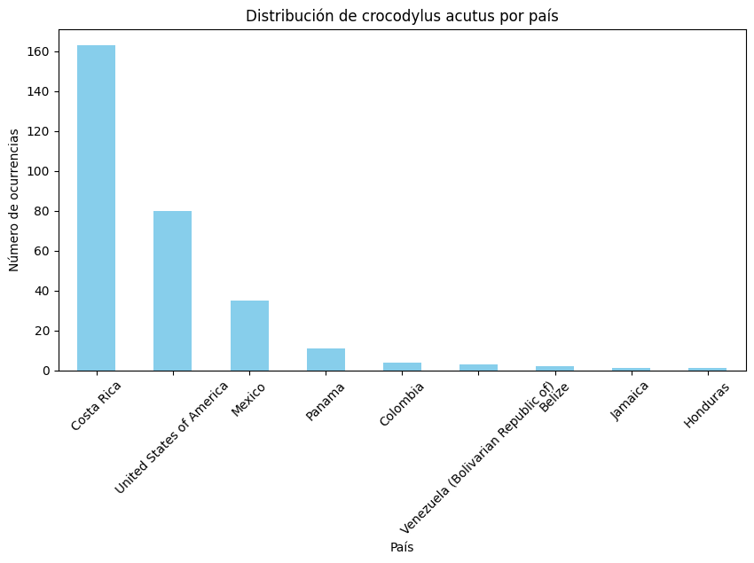

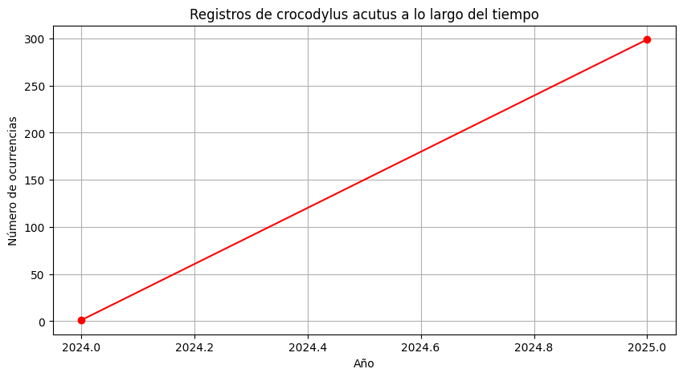

```python
# : Gráficos estadísticos

# Gráfico de barras: Ocurrencias por país
plt.figure(figsize=(10, 5))
df['country'].value_counts().plot(kind='bar', color='skyblue')
plt.xlabel("País")
plt.ylabel("Número de ocurrencias")
plt.title(f"Distribución de {taxon_name} por país")
plt.xticks(rotation=45)
plt.show()

# Gráfico de líneas: Ocurrencias por año
plt.figure(figsize=(10, 5))
df['year'].value_counts().sort_index().plot(kind='line', marker='o', color='red')
plt.xlabel("Año")
plt.ylabel("Número de ocurrencias")
plt.title(f"Registros de {taxon_name} a lo largo del tiempo")
plt.grid(True)
plt.show()
```

```python
# Paso 5: Generación de un mapa interactivo con registros de presencia
mapa = folium.Map(location=[df['decimalLatitude'].mean(), df['decimalLongitude'].mean()], zoom_start=4)

for _, row in df.iterrows():
    folium.CircleMarker(
        location=[row['decimalLatitude'], row['decimalLongitude']],
        radius=3,
        color='red',
        fill=True,
        fill_color='red',
        fill_opacity=0.6
    ).add_to(mapa)

# Mostrar el mapa interactivo
mapa
```

Make this Notebook Trusted to load map: File -> Trust Notebook

[interactive chart not shown]

# **Crocodylus acutus**

El cocodrilo americano, también conocido como lagarto real, lagarto amarillo o cocodrilo de río,2 asimismo como cocodrilo narigudo, cocodrilo aguja, cocodrilo de la costa3 (Ecuador), caimán de la costa (Venezuela), caimán aguja (Colombia) o cocodrilo de Tumbes (Perú) (Crocodylus acutus), pertenece a la familia de Crocodylidae. Se le suele confundir con aligátores (Alligator) con los cuales está poco emparentado, estos últimos son más próximos a los caimanes, como el yacaré overo (Caiman latirostris). La diferencia física entre ambos grupos es importante, lo que permite identificarlos sin problema.

# **Distribución**

Se lo encuentra desde la Florida, EE. UU. y México hasta el norte de Venezuela y Perú, incluyendo las islas de las Antillas, algunas islas del Mar Caribe y zonas costeras del golfo de México (incluyendo la península de Yucatán), hasta ríos de la costa caribeña de Honduras, Nicaragua, Costa Rica, Panamá, Colombia y Venezuela. En países como Perú y Ecuador7 la especie se halla en peligro crítico de extinción junto con el cocodrilo del Orinoco (Crocodylus intermedius). La caza implacable para obtener su piel redujo el número drásticamente en la década de 1960. Ahora hay restricciones que controlan el comercio de caimanes y sus pieles.

Una de las más grandes poblaciones de la especie en Sudamérica se encuentra en el Parque nacional Morrocoy en Venezuela donde se encuentran poblaciones de más de 500 especímenes, además de que los proyectos de conservación de la especie en dicho país liberan unas 100 crías por año.a